# Econometrics for dummies

Ralf Martin

# Dummies

A binary variable capturing a qualitative state in the data; e.g. female where we set the variable to 1 for women

```r
  wage1 <-  read.csv("https://www.dropbox.com/s/9agc2vmamfztlel/WAGE1.csv?dl=1")


  r1 <- lm(wage ~ female, wage1)
  r1 %>% summary()
```

```
##
## Call:
## lm(formula = wage ~ female, data = wage1)
##
## Residuals:
##     Min      1Q  Median      3Q     Max
## -5.5995 -1.8495 -0.9877  1.4260 17.8805
##
## Coefficients:
##             Estimate Std. Error t value Pr(>|t|)
## (Intercept)   7.0995     0.2100  33.806  < 2e-16 ***
## female       -2.5118     0.3034  -8.279 1.04e-15 ***
## ---
## Signif. codes:  0 '***' 0.001 '**' 0.01 '*' 0.05 '.' 0.1 ' ' 1
##
## Residual standard error: 3.476 on 524 degrees of freedom
## Multiple R-squared:  0.1157, Adjusted R-squared:  0.114
## F-statistic: 68.54 on 1 and 524 DF,  p-value: 1.042e-15
```

How can we interpret the coefficients?

$$Wage=\beta_0+\beta_1\times FEMALE+\epsilon$$

As before: by how much we can expect the dependent variable to change if we move one unit in the explanatory variable. Here this means if we go from a man to a women (or from a women to a man). In this case: women earn on average $2.51 less.

Note that

```r
wage1 %>% group_by(female) %>% summarize(mean(wage))
```

```
## # A tibble: 2 x 2
##   female `mean(wage)`
##    <int>        <dbl>
## 1      0         7.10
## 2      1         4.59
```

Notice, that the intercept ($\beta_0$) is the average wage for men. To get the average wage for women we need to add the coefficient:
$$E\{wage| Women\}=\beta_0+\beta_1=4.587...$$
where $E\{wage| Women\}$ is a mathematical way of saying the average (or expected) wage for women.

```r
  summary(r1)
```

```
##
## Call:
## lm(formula = wage ~ female, data = wage1)
##
## Residuals:
##     Min      1Q  Median      3Q     Max
## -5.5995 -1.8495 -0.9877  1.4260 17.8805
##
## Coefficients:
##             Estimate Std. Error t value Pr(>|t|)
## (Intercept)   7.0995     0.2100  33.806  < 2e-16 ***
## female       -2.5118     0.3034  -8.279 1.04e-15 ***
## ---
## Signif. codes:  0 '***' 0.001 '**' 0.01 '*' 0.05 '.' 0.1 ' ' 1
##
## Residual standard error: 3.476 on 524 degrees of freedom
## Multiple R-squared:  0.1157, Adjusted R-squared:  0.114
## F-statistic: 68.54 on 1 and 524 DF,  p-value: 1.042e-15
```

```r
  summary(lm(wage ~ 0+educ, wage1))
```

```
##
## Call:
## lm(formula = wage ~ 0 + educ, data = wage1)
##
## Residuals:
##    Min     1Q Median     3Q    Max
## -5.142 -2.246 -1.066  1.154 16.528
##
## Coefficients:
##      Estimate Std. Error t value Pr(>|t|)
## educ  0.47266    0.01146   41.25   <2e-16 ***
## ---
## Signif. codes:  0 '***' 0.001 '**' 0.01 '*' 0.05 '.' 0.1 ' ' 1
##
## Residual standard error: 3.381 on 525 degrees of freedom
## Multiple R-squared:  0.7642, Adjusted R-squared:  0.7637
## F-statistic:  1701 on 1 and 525 DF,  p-value: < 2.2e-16
```

```r
  rows=nrow(wage1)
  wage1["one"]<-rep(1,rows)
  head(wage1)
```

```
##   X wage educ exper tenure nonwhite female married numdep smsa northcen south
## 1 1 3.10   11     2      0        0      1       0      2    1        0     0
## 2 2 3.24   12    22      2        0      1       1      3    1        0     0
## 3 3 3.00   11     2      0        0      0       0      2    0        0     0
## 4 4 6.00    8    44     28        0      0       1      0    1        0     0
## 5 5 5.30   12     7      2        0      0       1      1    0        0     0
## 6 6 8.75   16     9      8        0      0       1      0    1        0     0
##   west construc ndurman trcommpu trade services profserv profocc clerocc
## 1    1        0       0        0     0        0        0       0       0
## 2    1        0       0        0     0        1        0       0       0
## 3    1        0       0        0     1        0        0       0       0
## 4    1        0       0        0     0        0        0       0       1
## 5    1        0       0        0     0        0        0       0       0
## 6    1        0       0        0     0        0        1       1       0
##   servocc    lwage expersq tenursq one
## 1       0 1.131402       4       0   1
## 2       1 1.175573     484       4   1
## 3       0 1.098612       4       0   1
## 4       0 1.791759    1936     784   1
## 5       0 1.667707      49       4   1
## 6       0 2.169054      81      64   1
```

```r
  summary(lm(wage ~ 0+educ+one, wage1))
```

```
##
## Call:
## lm(formula = wage ~ 0 + educ + one, data = wage1)
##
## Residuals:
##     Min      1Q  Median      3Q     Max
## -5.3396 -2.1501 -0.9674  1.1921 16.6085
##
## Coefficients:
##      Estimate Std. Error t value Pr(>|t|)
## educ  0.54136    0.05325  10.167   <2e-16 ***
## one  -0.90485    0.68497  -1.321    0.187
## ---
## Signif. codes:  0 '***' 0.001 '**' 0.01 '*' 0.05 '.' 0.1 ' ' 1
##
## Residual standard error: 3.378 on 524 degrees of freedom
## Multiple R-squared:  0.765,  Adjusted R-squared:  0.7641
## F-statistic: 852.7 on 2 and 524 DF,  p-value: < 2.2e-16
```

```r
  summary(lm(wage ~ educ+one, wage1))
```

```
##
## Call:
## lm(formula = wage ~ educ + one, data = wage1)
##
## Residuals:
##     Min      1Q  Median      3Q     Max
## -5.3396 -2.1501 -0.9674  1.1921 16.6085
##
## Coefficients: (1 not defined because of singularities)
##             Estimate Std. Error t value Pr(>|t|)
## (Intercept) -0.90485    0.68497  -1.321    0.187
## educ         0.54136    0.05325  10.167   <2e-16 ***
## one               NA         NA      NA       NA
## ---
## Signif. codes:  0 '***' 0.001 '**' 0.01 '*' 0.05 '.' 0.1 ' ' 1
##
## Residual standard error: 3.378 on 524 degrees of freedom
## Multiple R-squared:  0.1648, Adjusted R-squared:  0.1632
## F-statistic: 103.4 on 1 and 524 DF,  p-value: < 2.2e-16
```

```r
  summary(lm(wage ~one, wage1))
```

```
##
## Call:
## lm(formula = wage ~ one, data = wage1)
##
## Residuals:
##     Min      1Q  Median      3Q     Max
## -5.3661 -2.5661 -1.2461  0.9839 19.0839
##
## Coefficients: (1 not defined because of singularities)
##             Estimate Std. Error t value Pr(>|t|)
## (Intercept)    5.896      0.161   36.62   <2e-16 ***
## one               NA         NA      NA       NA
## ---
## Signif. codes:  0 '***' 0.001 '**' 0.01 '*' 0.05 '.' 0.1 ' ' 1
##
## Residual standard error: 3.693 on 525 degrees of freedom
```

```r
  summary(wage1$wage)
```

```
##    Min. 1st Qu.  Median    Mean 3rd Qu.    Max.
##   0.530   3.330   4.650   5.896   6.880  24.980
```

```r
  summary(lm(wage ~ female, wage1))
```

```
##
## Call:
## lm(formula = wage ~ female, data = wage1)
##
## Residuals:
##     Min      1Q  Median      3Q     Max
## -5.5995 -1.8495 -0.9877  1.4260 17.8805
##
## Coefficients:
##             Estimate Std. Error t value Pr(>|t|)
## (Intercept)   7.0995     0.2100  33.806  < 2e-16 ***
## female       -2.5118     0.3034  -8.279 1.04e-15 ***
## ---
## Signif. codes:  0 '***' 0.001 '**' 0.01 '*' 0.05 '.' 0.1 ' ' 1
##
## Residual standard error: 3.476 on 524 degrees of freedom
## Multiple R-squared:  0.1157, Adjusted R-squared:  0.114
## F-statistic: 68.54 on 1 and 524 DF,  p-value: 1.042e-15
```

```r
  aggregate(wage1$wage, list(wage1$female), mean)
```

```
##   Group.1        x
## 1       0 7.099489
## 2       1 4.587659
```

```r
  aggregate(wage1$wage, list(wage1$female), mean)
```

```
##   Group.1        x
## 1       0 7.099489
## 2       1 4.587659
```

```r
  wage1["male"]<-1-wage1$female

  summary(lm(wage ~ male +female, wage1))
```

```
##
## Call:
## lm(formula = wage ~ male + female, data = wage1)
##
## Residuals:
##     Min      1Q  Median      3Q     Max
## -5.5995 -1.8495 -0.9877  1.4260 17.8805
##
## Coefficients: (1 not defined because of singularities)
##             Estimate Std. Error t value Pr(>|t|)
## (Intercept)   4.5877     0.2190  20.950  < 2e-16 ***
## male          2.5118     0.3034   8.279 1.04e-15 ***
## female            NA         NA      NA       NA
## ---
## Signif. codes:  0 '***' 0.001 '**' 0.01 '*' 0.05 '.' 0.1 ' ' 1
##
## Residual standard error: 3.476 on 524 degrees of freedom
## Multiple R-squared:  0.1157, Adjusted R-squared:  0.114
## F-statistic: 68.54 on 1 and 524 DF,  p-value: 1.042e-15
```

```r
  summary(lm(wage ~ female+male , wage1))
```

```
##
## Call:
## lm(formula = wage ~ female + male, data = wage1)
##
## Residuals:
##     Min      1Q  Median      3Q     Max
## -5.5995 -1.8495 -0.9877  1.4260 17.8805
##
## Coefficients: (1 not defined because of singularities)
##             Estimate Std. Error t value Pr(>|t|)
## (Intercept)   7.0995     0.2100  33.806  < 2e-16 ***
## female       -2.5118     0.3034  -8.279 1.04e-15 ***
## male              NA         NA      NA       NA
## ---
## Signif. codes:  0 '***' 0.001 '**' 0.01 '*' 0.05 '.' 0.1 ' ' 1
##
## Residual standard error: 3.476 on 524 degrees of freedom
## Multiple R-squared:  0.1157, Adjusted R-squared:  0.114
## F-statistic: 68.54 on 1 and 524 DF,  p-value: 1.042e-15
```

```r
  summary(lm(wage ~ 0+male +female, wage1))
```

```
##
## Call:
## lm(formula = wage ~ 0 + male + female, data = wage1)
##
## Residuals:
##     Min      1Q  Median      3Q     Max
## -5.5995 -1.8495 -0.9877  1.4260 17.8805
##
## Coefficients:
##        Estimate Std. Error t value Pr(>|t|)
## male      7.099      0.210   33.81   <2e-16 ***
## female    4.588      0.219   20.95   <2e-16 ***
## ---
## Signif. codes:  0 '***' 0.001 '**' 0.01 '*' 0.05 '.' 0.1 ' ' 1
##
## Residual standard error: 3.476 on 524 degrees of freedom
## Multiple R-squared:  0.7512, Adjusted R-squared:  0.7502
## F-statistic: 790.9 on 2 and 524 DF,  p-value: < 2.2e-16
```

# Dummies and categorical variables

```r
wage1= wage1 %>% mutate(educats=0,
                        educats=ifelse(educ==12,1,educats),
                        educats=ifelse(educ>12,2,educats))

wage1 %>% group_by(educats) %>% summarize(n())
```

```
## # A tibble: 3 x 2
##   educats `n()`
##     <dbl> <int>
## 1       0   116
## 2       1   198
## 3       2   212
```

```r
summary(lm(wage~educats,wage1))
```

```
##
## Call:
## lm(formula = wage ~ educats, data = wage1)
##
## Residuals:
##     Min      1Q  Median      3Q     Max
## -5.2933 -2.2542 -0.9292  1.2301 17.6867
##
## Coefficients:
##             Estimate Std. Error t value Pr(>|t|)
## (Intercept)   3.8751     0.2765  14.016   <2e-16 ***
## educats       1.7091     0.1961   8.717   <2e-16 ***
## ---
## Signif. codes:  0 '***' 0.001 '**' 0.01 '*' 0.05 '.' 0.1 ' ' 1
##
## Residual standard error: 3.455 on 524 degrees of freedom
## Multiple R-squared:  0.1267, Adjusted R-squared:  0.125
## F-statistic: 75.99 on 1 and 524 DF,  p-value: < 2.2e-16
```

Making a set of dummy variables

```r
wage1=wage1 %>% mutate(edu_low=educats==0,
                       edu_normal=educats==1,
                       edu_high=educats==2)

reg=lm(wage~edu_low+edu_normal+edu_high,wage1)

reg %>% summary()
```

```
##
## Call:
## lm(formula = wage ~ edu_low + edu_normal + edu_high, data = wage1)
##
## Residuals:
##    Min     1Q Median     3Q    Max
## -5.393 -2.119 -1.033  1.245 17.587
##
## Coefficients: (1 not defined because of singularities)
##                Estimate Std. Error t value Pr(>|t|)
## (Intercept)      7.3926     0.2372  31.165  < 2e-16 ***
## edu_lowTRUE     -3.3359     0.3989  -8.363 5.56e-16 ***
## edu_normalTRUE  -2.0213     0.3413  -5.922 5.78e-09 ***
## edu_highTRUE         NA         NA      NA       NA
## ---
## Signif. codes:  0 '***' 0.001 '**' 0.01 '*' 0.05 '.' 0.1 ' ' 1
##
## Residual standard error: 3.454 on 523 degrees of freedom
## Multiple R-squared:  0.1287, Adjusted R-squared:  0.1254
## F-statistic: 38.64 on 2 and 523 DF,  p-value: 2.236e-16
```

## Testing for a linear relationship

```r
  library(car)

  summary(lm(wage ~ edu_low+edu_normal+edu_high, wage1))
```

```
##
## Call:
## lm(formula = wage ~ edu_low + edu_normal + edu_high, data = wage1)
##
## Residuals:
##    Min     1Q Median     3Q    Max
## -5.393 -2.119 -1.033  1.245 17.587
##
## Coefficients: (1 not defined because of singularities)
##                Estimate Std. Error t value Pr(>|t|)
## (Intercept)      7.3926     0.2372  31.165  < 2e-16 ***
## edu_lowTRUE     -3.3359     0.3989  -8.363 5.56e-16 ***
## edu_normalTRUE  -2.0213     0.3413  -5.922 5.78e-09 ***
## edu_highTRUE         NA         NA      NA       NA
## ---
## Signif. codes:  0 '***' 0.001 '**' 0.01 '*' 0.05 '.' 0.1 ' ' 1
##
## Residual standard error: 3.454 on 523 degrees of freedom
## Multiple R-squared:  0.1287, Adjusted R-squared:  0.1254
## F-statistic: 38.64 on 2 and 523 DF,  p-value: 2.236e-16
```

```r
  reg=lm(wage ~ edu_low+edu_high, wage1)

  linearHypothesis(reg,c("edu_lowTRUE=-edu_highTRUE"))
```

```
## Linear hypothesis test
##
## Hypothesis:
## edu_lowTRUE  + edu_highTRUE = 0
##
## Model 1: restricted model
## Model 2: wage ~ edu_low + edu_high
##
##   Res.Df    RSS Df Sum of Sq      F Pr(>F)
## 1    524 6253.5
## 2    523 6238.6  1    14.888 1.2481 0.2644
```

## Factor variables

```r
wage1 =wage1 %>% mutate(educatsf=factor(educats,label=c("low","normal","high")))
```

Compare:

```r
wage1 %>% group_by(educatsf) %>% summarise(n())
```

```
## # A tibble: 3 x 2
##   educatsf `n()`
##   <fct>    <int>
## 1 low        116
## 2 normal     198
## 3 high       212
```

```r
wage1 %>% group_by(educats) %>% summarise(n())
```

```
## # A tibble: 3 x 2
##   educats `n()`
##     <dbl> <int>
## 1       0   116
## 2       1   198
## 3       2   212
```

Running the same regression again:

```r
reg2=lm(wage ~ educatsf, wage1)
reg2 %>% summary()
```

```
##
## Call:
## lm(formula = wage ~ educatsf, data = wage1)
##
## Residuals:
##    Min     1Q Median     3Q    Max
## -5.393 -2.119 -1.033  1.245 17.587
##
## Coefficients:
##                Estimate Std. Error t value Pr(>|t|)
## (Intercept)      4.0567     0.3207  12.651  < 2e-16 ***
## educatsfnormal   1.3146     0.4038   3.255  0.00121 **
## educatsfhigh     3.3359     0.3989   8.363 5.56e-16 ***
## ---
## Signif. codes:  0 '***' 0.001 '**' 0.01 '*' 0.05 '.' 0.1 ' ' 1
##
## Residual standard error: 3.454 on 523 degrees of freedom
## Multiple R-squared:  0.1287, Adjusted R-squared:  0.1254
## F-statistic: 38.64 on 2 and 523 DF,  p-value: 2.236e-16
```

# Dummies as dependent variable

```r
  bm=read.csv("https://www.dropbox.com/s/e4w6pjm6b4wz9do/bm.csv?dl=1")


  summary(lm(call~ofjobs+computerskills+education,bm))
```

```
##
## Call:
## lm(formula = call ~ ofjobs + computerskills + education, data = bm)
##
## Residuals:
##      Min       1Q   Median       3Q      Max
## -0.10351 -0.07902 -0.07626 -0.07607  0.92788
##
## Coefficients:
##                 Estimate Std. Error t value Pr(>|t|)
## (Intercept)     0.101742   0.022776   4.467 8.11e-06 ***
## ofjobs          0.001381   0.003287   0.420    0.674
## computerskills -0.020734   0.010194  -2.034    0.042 *
## education      -0.002569   0.005586  -0.460    0.646
## ---
## Signif. codes:  0 '***' 0.001 '**' 0.01 '*' 0.05 '.' 0.1 ' ' 1
##
## Residual standard error: 0.272 on 4866 degrees of freedom
## Multiple R-squared:  0.0008958,  Adjusted R-squared:  0.0002798
## F-statistic: 1.454 on 3 and 4866 DF,  p-value: 0.225
```

```r
  summary(lm(call~education,bm))
```

```
##
## Call:
## lm(formula = call ~ education, data = bm)
##
## Residuals:
##      Min       1Q   Median       3Q      Max
## -0.08841 -0.08185 -0.07966 -0.07966  0.92034
##
## Coefficients:
##              Estimate Std. Error t value Pr(>|t|)
## (Intercept)  0.088407   0.020117   4.395 1.13e-05 ***
## education   -0.002187   0.005454  -0.401    0.688
## ---
## Signif. codes:  0 '***' 0.001 '**' 0.01 '*' 0.05 '.' 0.1 ' ' 1
##
## Residual standard error: 0.2721 on 4868 degrees of freedom
## Multiple R-squared:  3.304e-05,  Adjusted R-squared:  -0.0001724
## F-statistic: 0.1608 on 1 and 4868 DF,  p-value: 0.6884
```

```r
summary(lm(call~black,bm))
```

```
##
## Call:
## lm(formula = call ~ black, data = bm)
##
## Residuals:
##      Min       1Q   Median       3Q      Max
## -0.09651 -0.09651 -0.06448 -0.06448  0.93552
##
## Coefficients:
##              Estimate Std. Error t value Pr(>|t|)
## (Intercept)  0.096509   0.005505  17.532  < 2e-16 ***
## black       -0.032033   0.007785  -4.115 3.94e-05 ***
## ---
## Signif. codes:  0 '***' 0.001 '**' 0.01 '*' 0.05 '.' 0.1 ' ' 1
##
## Residual standard error: 0.2716 on 4868 degrees of freedom
## Multiple R-squared:  0.003466,   Adjusted R-squared:  0.003261
## F-statistic: 16.93 on 1 and 4868 DF,  p-value: 3.941e-05
```

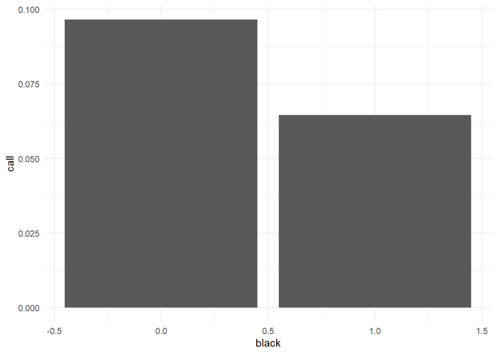

```r
library(ggplot2)
agg=bm %>% group_by(black) %>% summarise(call=mean(call))
ggplot(agg,aes(x=black,y=call))+geom_bar(stat="identity")+theme_minimal()
```

What about continous explanatory variables?

```r
(linear0 <- lm(call ~ yearsexp        , data = bm)) %>% summary()
```

```
##
## Call:
## lm(formula = call ~ yearsexp, data = bm)
##
## Residuals:
##      Min       1Q   Median       3Q      Max
## -0.20030 -0.08101 -0.07439 -0.06776  0.94218
##
## Coefficients:
##              Estimate Std. Error t value Pr(>|t|)
## (Intercept) 0.0545046  0.0071949   7.575 4.26e-14 ***
## yearsexp    0.0033136  0.0007716   4.295 1.78e-05 ***
## ---
## Signif. codes:  0 '***' 0.001 '**' 0.01 '*' 0.05 '.' 0.1 ' ' 1
##
## Residual standard error: 0.2716 on 4868 degrees of freedom
## Multiple R-squared:  0.003774,   Adjusted R-squared:  0.00357
## F-statistic: 18.44 on 1 and 4868 DF,  p-value: 1.784e-05
```

```r
(linear1 <- lm(call ~ factor(yearsexp), data = bm)) %>% summary()
```

```
##
## Call:
## lm(formula = call ~ factor(yearsexp), data = bm)
##
## Residuals:
##      Min       1Q   Median       3Q      Max
## -0.25000 -0.08194 -0.07246 -0.05998  0.97059
##
## Coefficients:
##                      Estimate Std. Error t value Pr(>|t|)
## (Intercept)         0.0666667  0.0404239   1.649   0.0992 .
## factor(yearsexp)2  -0.0041667  0.0429301  -0.097   0.9227
## factor(yearsexp)3  -0.0202749  0.0448679  -0.452   0.6514
## factor(yearsexp)4   0.0152700  0.0420835   0.363   0.7167
## factor(yearsexp)5   0.0043393  0.0421797   0.103   0.9181
## factor(yearsexp)6  -0.0066911  0.0415222  -0.161   0.8720
## factor(yearsexp)7   0.0109673  0.0420715   0.261   0.7943
## factor(yearsexp)8   0.0059977  0.0419680   0.143   0.8864
## factor(yearsexp)9   0.0276730  0.0457883   0.604   0.5456
## factor(yearsexp)10  0.0487179  0.0469013   1.039   0.2990
## factor(yearsexp)11  0.0373796  0.0453778   0.824   0.4101
## factor(yearsexp)12  0.0057971  0.0519596   0.112   0.9112
## factor(yearsexp)13  0.1021645  0.0459520   2.223   0.0262 *
## factor(yearsexp)14  0.0004474  0.0461260   0.010   0.9923
## factor(yearsexp)15 -0.0372549  0.0616186  -0.605   0.5455
## factor(yearsexp)16  0.0929078  0.0491566   1.890   0.0588 .
## factor(yearsexp)17 -0.0666667  0.1616955  -0.412   0.6801
## factor(yearsexp)18  0.0242424  0.0508830   0.476   0.6338
## factor(yearsexp)19  0.0855072  0.0568565   1.504   0.1327
## factor(yearsexp)20  0.1333333  0.0611152   2.182   0.0292 *
## factor(yearsexp)21  0.0609929  0.0565566   1.078   0.2809
## factor(yearsexp)22  0.1833333  0.1040473   1.762   0.0781 .
## factor(yearsexp)23 -0.0666667  0.0990179  -0.673   0.5008
## factor(yearsexp)25 -0.0666667  0.1101769  -0.605   0.5451
## factor(yearsexp)26  0.0391026  0.0483854   0.808   0.4190
## factor(yearsexp)44 -0.0666667  0.2741681  -0.243   0.8079
## ---
## Signif. codes:  0 '***' 0.001 '**' 0.01 '*' 0.05 '.' 0.1 ' ' 1
##
## Residual standard error: 0.2712 on 4844 degrees of freedom
## Multiple R-squared:  0.01179,    Adjusted R-squared:  0.006685
## F-statistic: 2.311 on 25 and 4844 DF,  p-value: 0.0002247
```

Student Question: A stepwise linear model?

```r
bm= bm %>% mutate(moret10=yearsexp>10,

                  moret10Xyearsexp=moret10*yearsexp,


                  dev=ifelse(moret10==T, yearsexp-10,yearsexp))


lm(call ~ yearsexp        , data = bm) %>% summary()
```

```
##
## Call:
## lm(formula = call ~ yearsexp, data = bm)
##
## Residuals:
##      Min       1Q   Median       3Q      Max
## -0.20030 -0.08101 -0.07439 -0.06776  0.94218
##
## Coefficients:
##              Estimate Std. Error t value Pr(>|t|)
## (Intercept) 0.0545046  0.0071949   7.575 4.26e-14 ***
## yearsexp    0.0033136  0.0007716   4.295 1.78e-05 ***
## ---
## Signif. codes:  0 '***' 0.001 '**' 0.01 '*' 0.05 '.' 0.1 ' ' 1
##
## Residual standard error: 0.2716 on 4868 degrees of freedom
## Multiple R-squared:  0.003774,   Adjusted R-squared:  0.00357
## F-statistic: 18.44 on 1 and 4868 DF,  p-value: 1.784e-05
```

```r
lm(call ~ yearsexp+moret10        , data = bm) %>% summary()
```

```
##
## Call:
## lm(formula = call ~ yearsexp + moret10, data = bm)
##
## Residuals:
##      Min       1Q   Median       3Q      Max
## -0.15966 -0.07550 -0.07223 -0.06896  0.93594
##
## Coefficients:
##             Estimate Std. Error t value Pr(>|t|)
## (Intercept) 0.062423   0.008940   6.982  3.3e-12 ***
## yearsexp    0.001634   0.001365   1.197    0.231
## moret10TRUE 0.025329   0.016979   1.492    0.136
## ---
## Signif. codes:  0 '***' 0.001 '**' 0.01 '*' 0.05 '.' 0.1 ' ' 1
##
## Residual standard error: 0.2716 on 4867 degrees of freedom
## Multiple R-squared:  0.00423,    Adjusted R-squared:  0.003821
## F-statistic: 10.34 on 2 and 4867 DF,  p-value: 3.314e-05
```

```r
res=lm(call ~ yearsexp+moret10+moret10Xyearsexp        , data = bm)
res %>% summary()
```

```
##
## Call:
## lm(formula = call ~ yearsexp + moret10 + moret10Xyearsexp, data = bm)
##
## Residuals:
##      Min       1Q   Median       3Q      Max
## -0.12465 -0.07921 -0.07269 -0.06617  0.94360
##
## Coefficients:
##                   Estimate Std. Error t value Pr(>|t|)
## (Intercept)       0.053137   0.012612   4.213 2.56e-05 ***
## yearsexp          0.003259   0.002070   1.574   0.1155
## moret10TRUE       0.054572   0.032757   1.666   0.0958 .
## moret10Xyearsexp -0.002874   0.002753  -1.044   0.2966
## ---
## Signif. codes:  0 '***' 0.001 '**' 0.01 '*' 0.05 '.' 0.1 ' ' 1
##
## Residual standard error: 0.2716 on 4866 degrees of freedom
## Multiple R-squared:  0.004453,   Adjusted R-squared:  0.003839
## F-statistic: 7.255 on 3 and 4866 DF,  p-value: 7.469e-05
```

```r
lm(call ~ yearsexp+moret10Xyearsexp        , data = bm) %>% summary()
```

```
##
## Call:
## lm(formula = call ~ yearsexp + moret10Xyearsexp, data = bm)
##
## Residuals:
##      Min       1Q   Median       3Q      Max
## -0.19595 -0.07734 -0.07331 -0.06928  0.93676
##
## Coefficients:
##                  Estimate Std. Error t value Pr(>|t|)
## (Intercept)      0.061226   0.011642   5.259 1.51e-07 ***
## yearsexp         0.002014   0.001931   1.043    0.297
## moret10Xyearsexp 0.001048   0.001427   0.734    0.463
## ---
## Signif. codes:  0 '***' 0.001 '**' 0.01 '*' 0.05 '.' 0.1 ' ' 1
##
## Residual standard error: 0.2716 on 4867 degrees of freedom
## Multiple R-squared:  0.003885,   Adjusted R-squared:  0.003476
## F-statistic: 9.491 on 2 and 4867 DF,  p-value: 7.696e-05
```

$$y=\beta_1 + \beta_2 exper + \beta_3 MT10 + \beta_4 MT10 \times exper$$

say we are at 15 years

$$y=\beta_1+ \beta_3 + (\beta_2 + \beta_4 )exper$$

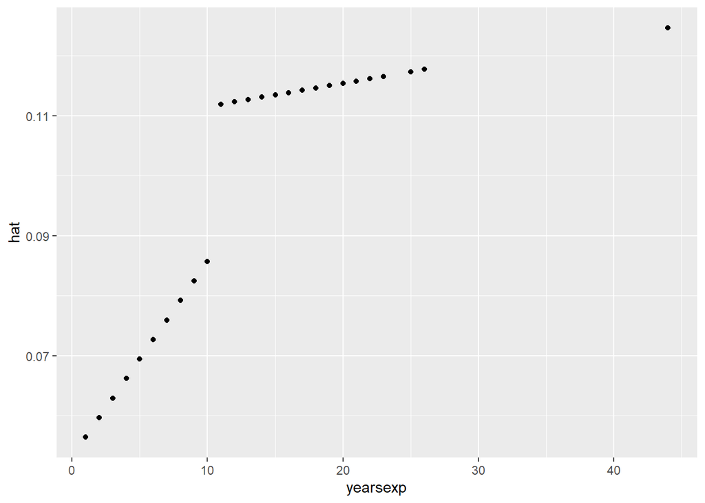

```r
bm=bm %>% mutate(hat=res$coefficients[[1]] +
                     res$coefficients[[2]] * yearsexp+
                     res$coefficients[[3]] * moret10 +
                     res$coefficients[[4]] * moret10Xyearsexp )

ggplot(bm, aes(x=yearsexp,y=hat))+geom_point()
```

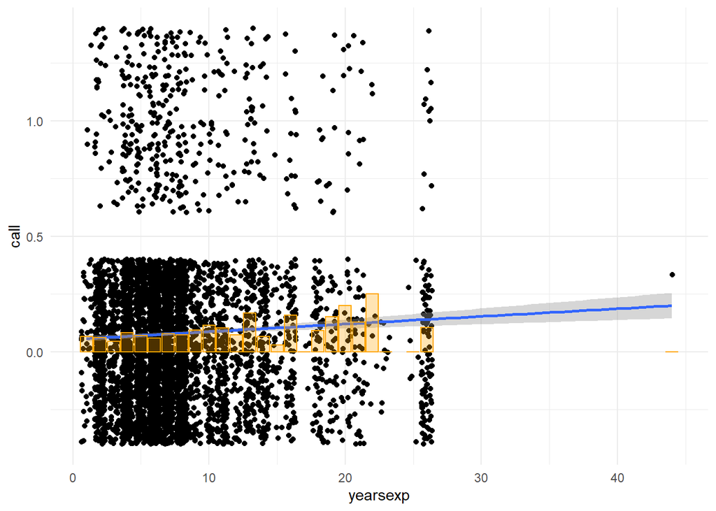

```r
agg2=agg=bm %>% group_by(yearsexp) %>% summarise(call=mean(call))
ggplot(bm,aes(x=yearsexp,y=call) ) + geom_jitter()+
           geom_smooth(method="lm")+
           geom_bar(data=agg2,aes(x=yearsexp,y=call),
                    stat="identity",color="orange",
                    fill="orange",alpha=0.3)+
          theme_minimal()
```

```r
  summary(lm(call~yearsexp,bm))
```

```
##
## Call:
## lm(formula = call ~ yearsexp, data = bm)
##
## Residuals:
##      Min       1Q   Median       3Q      Max
## -0.20030 -0.08101 -0.07439 -0.06776  0.94218
##
## Coefficients:
##              Estimate Std. Error t value Pr(>|t|)
## (Intercept) 0.0545046  0.0071949   7.575 4.26e-14 ***
## yearsexp    0.0033136  0.0007716   4.295 1.78e-05 ***
## ---
## Signif. codes:  0 '***' 0.001 '**' 0.01 '*' 0.05 '.' 0.1 ' ' 1
##
## Residual standard error: 0.2716 on 4868 degrees of freedom
## Multiple R-squared:  0.003774,   Adjusted R-squared:  0.00357
## F-statistic: 18.44 on 1 and 4868 DF,  p-value: 1.784e-05
```

```r
  summary(linear2 <- lm(call ~ black, data = bm))
```

```
##
## Call:
## lm(formula = call ~ black, data = bm)
##
## Residuals:
##      Min       1Q   Median       3Q      Max
## -0.09651 -0.09651 -0.06448 -0.06448  0.93552
##
## Coefficients:
##              Estimate Std. Error t value Pr(>|t|)
## (Intercept)  0.096509   0.005505  17.532  < 2e-16 ***
## black       -0.032033   0.007785  -4.115 3.94e-05 ***
## ---
## Signif. codes:  0 '***' 0.001 '**' 0.01 '*' 0.05 '.' 0.1 ' ' 1
##
## Residual standard error: 0.2716 on 4868 degrees of freedom
## Multiple R-squared:  0.003466,   Adjusted R-squared:  0.003261
## F-statistic: 16.93 on 1 and 4868 DF,  p-value: 3.941e-05
```

```r
  summary(linear1 <- lm(call ~ yearsexp, data = bm))
```

```
##
## Call:
## lm(formula = call ~ yearsexp, data = bm)
##
## Residuals:
##      Min       1Q   Median       3Q      Max
## -0.20030 -0.08101 -0.07439 -0.06776  0.94218
##
## Coefficients:
##              Estimate Std. Error t value Pr(>|t|)
## (Intercept) 0.0545046  0.0071949   7.575 4.26e-14 ***
## yearsexp    0.0033136  0.0007716   4.295 1.78e-05 ***
## ---
## Signif. codes:  0 '***' 0.001 '**' 0.01 '*' 0.05 '.' 0.1 ' ' 1
##
## Residual standard error: 0.2716 on 4868 degrees of freedom
## Multiple R-squared:  0.003774,   Adjusted R-squared:  0.00357
## F-statistic: 18.44 on 1 and 4868 DF,  p-value: 1.784e-05
```

```r
  library(aod)
  library(margins)
  summary(logit1 <- glm(call ~ yearsexp, data = bm, family = "binomial"))
```

```
##
## Call:
## glm(formula = call ~ yearsexp, family = "binomial", data = bm)
##
## Deviance Residuals:
##     Min       1Q   Median       3Q      Max
## -0.7780  -0.4075  -0.3924  -0.3779   2.3598
##
## Coefficients:
##             Estimate Std. Error z value Pr(>|z|)
## (Intercept) -2.75960    0.09620 -28.687  < 2e-16 ***
## yearsexp     0.03908    0.00918   4.257 2.07e-05 ***
## ---
## Signif. codes:  0 '***' 0.001 '**' 0.01 '*' 0.05 '.' 0.1 ' ' 1
##
## (Dispersion parameter for binomial family taken to be 1)
##
##     Null deviance: 2726.9  on 4869  degrees of freedom
## Residual deviance: 2710.2  on 4868  degrees of freedom
## AIC: 2714.2
##
## Number of Fisher Scoring iterations: 5
```

```r
  summary(linear1)
```

```
##
## Call:
## lm(formula = call ~ yearsexp, data = bm)
##
## Residuals:
##      Min       1Q   Median       3Q      Max
## -0.20030 -0.08101 -0.07439 -0.06776  0.94218
##
## Coefficients:
##              Estimate Std. Error t value Pr(>|t|)
## (Intercept) 0.0545046  0.0071949   7.575 4.26e-14 ***
## yearsexp    0.0033136  0.0007716   4.295 1.78e-05 ***
## ---
## Signif. codes:  0 '***' 0.001 '**' 0.01 '*' 0.05 '.' 0.1 ' ' 1
##
## Residual standard error: 0.2716 on 4868 degrees of freedom
## Multiple R-squared:  0.003774,   Adjusted R-squared:  0.00357
## F-statistic: 18.44 on 1 and 4868 DF,  p-value: 1.784e-05
```

```r
  margins(logit1)
```

```
## Average marginal effects
```

```
## glm(formula = call ~ yearsexp, family = "binomial", data = bm)
```

```
##  yearsexp
##  0.002881
```

```r
  log(100)
```

```
## [1] 4.60517
```

Note that the linear model is fairly close to the average marginal effect

```r
  summary(logit2 <- glm(call ~ black, data = bm, family = "binomial"))
```

```
##
## Call:
## glm(formula = call ~ black, family = "binomial", data = bm)
##
## Deviance Residuals:
##     Min       1Q   Median       3Q      Max
## -0.4505  -0.4505  -0.3651  -0.3651   2.3416
##
## Coefficients:
##             Estimate Std. Error z value Pr(>|z|)
## (Intercept) -2.23663    0.06863 -32.590  < 2e-16 ***
## black       -0.43818    0.10732  -4.083 4.45e-05 ***
## ---
## Signif. codes:  0 '***' 0.001 '**' 0.01 '*' 0.05 '.' 0.1 ' ' 1
##
## (Dispersion parameter for binomial family taken to be 1)
##
##     Null deviance: 2726.9  on 4869  degrees of freedom
## Residual deviance: 2709.9  on 4868  degrees of freedom
## AIC: 2713.9
##
## Number of Fisher Scoring iterations: 5
```

```r
  #summary(linear2)
  margins(logit2)
```

```
## Average marginal effects
```

```
## glm(formula = call ~ black, family = "binomial", data = bm)
```

```
##     black
##  -0.03232
```

```r
  summary(logit3 <- glm(call ~ black+yearsexp, data = bm, family = "binomial"))
```

```
##
## Call:
## glm(formula = call ~ black + yearsexp, family = "binomial", data = bm)
##
## Deviance Residuals:
##     Min       1Q   Median       3Q      Max
## -0.7008  -0.4318  -0.4006  -0.3496   2.4537
##
## Coefficients:
##              Estimate Std. Error z value Pr(>|z|)
## (Intercept) -2.560532   0.105784 -24.205  < 2e-16 ***
## black       -0.438409   0.107523  -4.077 4.56e-05 ***
## yearsexp     0.039089   0.009199   4.249 2.14e-05 ***
## ---
## Signif. codes:  0 '***' 0.001 '**' 0.01 '*' 0.05 '.' 0.1 ' ' 1
##
## (Dispersion parameter for binomial family taken to be 1)
##
##     Null deviance: 2726.9  on 4869  degrees of freedom
## Residual deviance: 2693.2  on 4867  degrees of freedom
## AIC: 2699.2
##
## Number of Fisher Scoring iterations: 5
```

```r
  summary(linear3<- lm(call ~ black+ yearsexp, data = bm))
```

```
##
## Call:
## lm(formula = call ~ black + yearsexp, data = bm)
##
## Residuals:
##      Min       1Q   Median       3Q      Max
## -0.18403 -0.09148 -0.07715 -0.05843  0.95810
##
## Coefficients:
##               Estimate Std. Error t value Pr(>|t|)
## (Intercept)  0.0705426  0.0081743   8.630  < 2e-16 ***
## black       -0.0319446  0.0077711  -4.111 4.01e-05 ***
## yearsexp     0.0033052  0.0007703   4.291 1.82e-05 ***
## ---
## Signif. codes:  0 '***' 0.001 '**' 0.01 '*' 0.05 '.' 0.1 ' ' 1
##
## Residual standard error: 0.2712 on 4867 degrees of freedom
## Multiple R-squared:  0.007221,   Adjusted R-squared:  0.006813
## F-statistic:  17.7 on 2 and 4867 DF,  p-value: 2.19e-08
```

```r
  margins(logit3)
```

```
## Average marginal effects
```

```
## glm(formula = call ~ black + yearsexp, family = "binomial", data = bm)
```

```
##     black yearsexp
##  -0.03221 0.002872
```

```r
  margins(linear3)
```

```
## Average marginal effects
```

```
## lm(formula = call ~ black + yearsexp, data = bm)
```

```
##     black yearsexp
##  -0.03194 0.003305
```

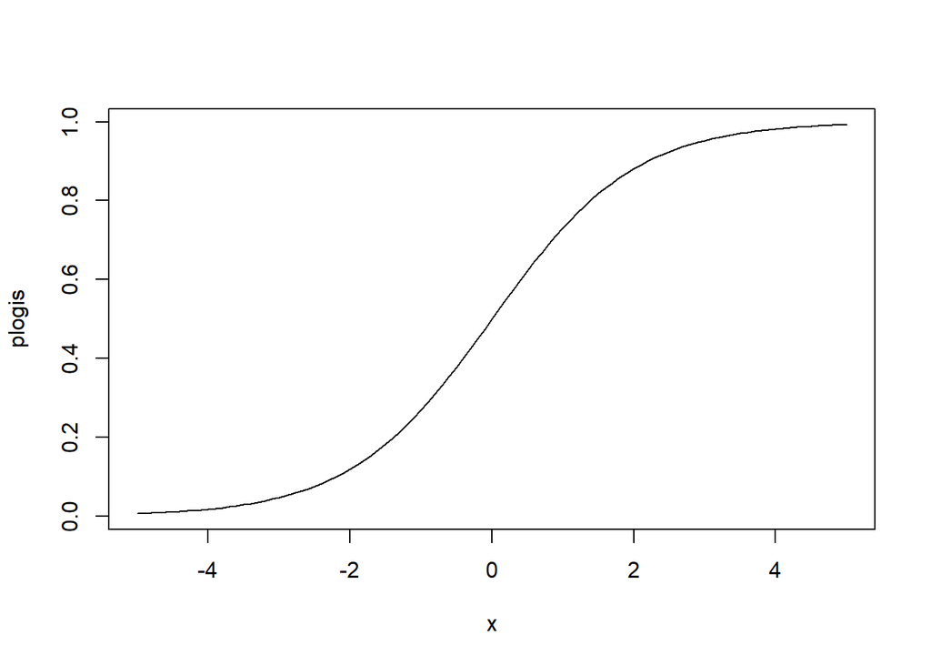

```r
  #test=lm(call~ yearsexp*education,bm)

  #mar=margins(test,type="response")

  plot(plogis,-5 ,5, )
```

```r
  plogis(2)
```

```
## [1] 0.8807971
```

```r
  bm["callstar1"] = plogis(-2.7+bm$yearsexp * .3)
  bm["callstar2"] = plogis( -2.7+bm$yearsexp * 0.06)
  bm["callstar3"] = plogis( -5+bm$yearsexp * 0.06)

  bm["callstar4"] = plogis(-1 +bm$yearsexp*.8 )

  summary(bm$callstar1)
```

```
##    Min. 1st Qu.  Median    Mean 3rd Qu.    Max.
## 0.08317 0.23148 0.28905 0.40104 0.50000 0.99997
```

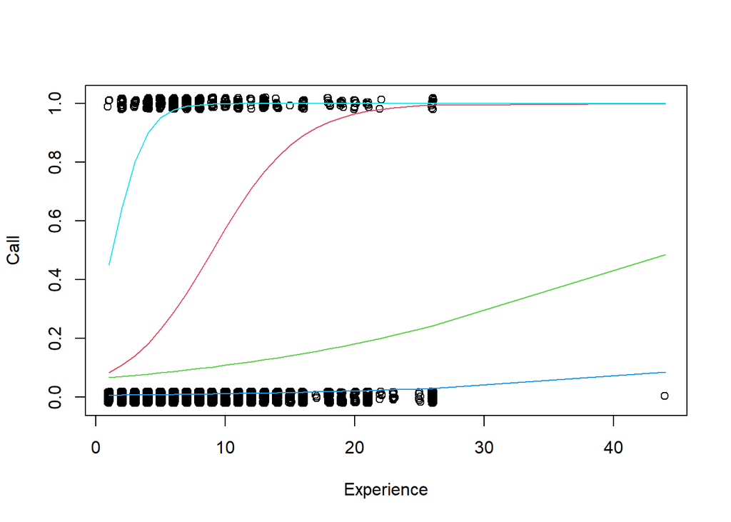

```r
  bm=bm[order(bm$yearsexp),]

  bm["yearsexp_rand"]=bm$yearsexp+runif( nrow(bm),min = -0.1, max = .1)
  bm["call_rand"]=bm$call+runif( nrow(bm),min = -0.02, max = .02)

  plot(bm$yearsexp_rand, bm$call_rand,  main="",
       xlab="Experience", ylab="Call", pch=1)

  lines(bm$yearsexp, bm$callstar1  ,col=2)
  lines(bm$yearsexp, bm$callstar2  ,col=3)
  lines(bm$yearsexp, bm$callstar3  ,col=4)
  lines(bm$yearsexp, bm$callstar4  ,col=5)
```

# Nonlinear

```r
  wage1=wage1 %>% mutate(educ2 =educ^2)
  summary(lm(wage ~ educ+educ2, wage1))
```

```
##
## Call:
## lm(formula = wage ~ educ + educ2, data = wage1)
##
## Residuals:
##     Min      1Q  Median      3Q     Max
## -6.8722 -2.0002 -0.7472  1.2642 17.0159
##
## Coefficients:
##             Estimate Std. Error t value Pr(>|t|)
## (Intercept)  5.40769    1.45886   3.707 0.000232 ***
## educ        -0.60750    0.24149  -2.516 0.012181 *
## educ2        0.04907    0.01007   4.872 1.46e-06 ***
## ---
## Signif. codes:  0 '***' 0.001 '**' 0.01 '*' 0.05 '.' 0.1 ' ' 1
##
## Residual standard error: 3.307 on 523 degrees of freedom
## Multiple R-squared:  0.201,  Adjusted R-squared:  0.198
## F-statistic: 65.79 on 2 and 523 DF,  p-value: < 2.2e-16
```

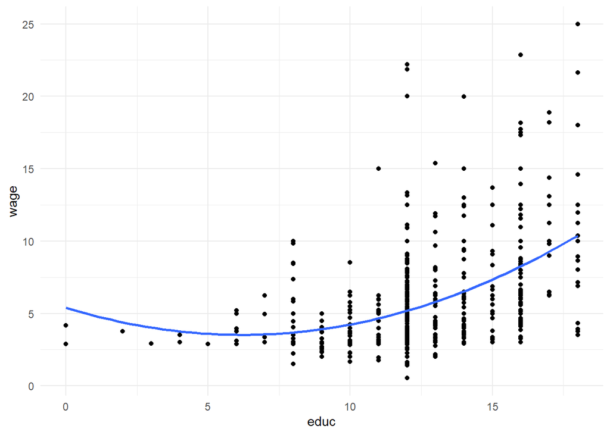

```r
  library(ggplot2)

  ggplot(wage1, aes(x=educ, y=wage))+geom_point()+theme_minimal()+
    geom_smooth(method=lm,se=FALSE,formula=y ~ poly(x, 2))
```

# log linear

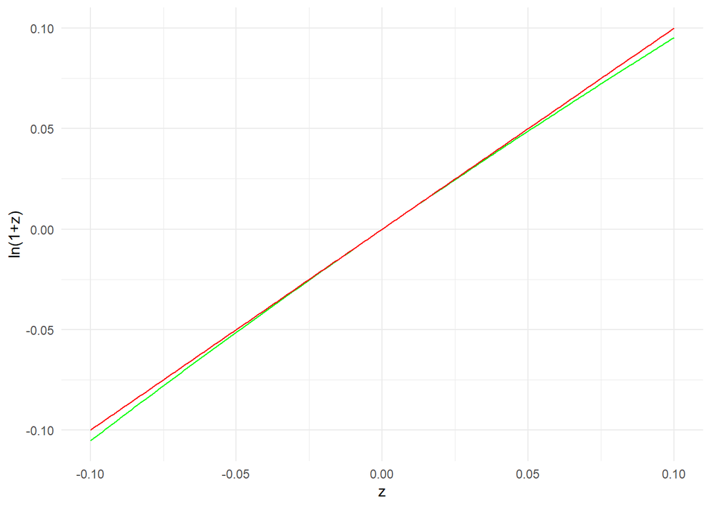

```r
  library(ggplot2)
  z=seq(-.1,.1,.001)
  ln1Pz=log(1+z)
  df=data.frame(z,ln1Pz)
  ggplot(df,aes(x=z))+geom_line(aes(y=ln1Pz),color="green")+
            geom_line(aes(y=z),color="red") + theme_minimal() + ylab("ln(1+z)")
```

# Many dummies as control

```r
library(dplyr)
prod=read.csv("https://www.dropbox.com/s/v1j4xzkaado8zlz/prod_balanced.csv?dl=1")
prod=prod %>% mutate(lnl=log(l),lnva=log(va))
prod=prod %>% arrange(id,year) %>% select(id,year,va,l,k,lnk,lnl,lnva)


reg1<-lm(lnva~lnl+lnk,prod)
reg1 %>% summary()
```

```
##
## Call:
## lm(formula = lnva ~ lnl + lnk, data = prod)
##
## Residuals:
##     Min      1Q  Median      3Q     Max
## -3.8415 -0.4453  0.0326  0.4820  3.0979
##
## Coefficients:
##             Estimate Std. Error t value Pr(>|t|)
## (Intercept) 3.423770   0.034256   99.95   <2e-16 ***
## lnl         0.950352   0.010352   91.81   <2e-16 ***
## lnk         0.304229   0.005801   52.45   <2e-16 ***
## ---
## Signif. codes:  0 '***' 0.001 '**' 0.01 '*' 0.05 '.' 0.1 ' ' 1
##
## Residual standard error: 0.7568 on 14501 degrees of freedom
## Multiple R-squared:  0.7483, Adjusted R-squared:  0.7482
## F-statistic: 2.155e+04 on 2 and 14501 DF,  p-value: < 2.2e-16
```

```r
reg2<-lm(lnva~lnl+lnk+factor(year),prod)
reg2 %>% summary()
```

```
##
## Call:
## lm(formula = lnva ~ lnl + lnk + factor(year), data = prod)
##
## Residuals:
##     Min      1Q  Median      3Q     Max
## -3.9437 -0.4423  0.0321  0.4801  3.0727
##
## Coefficients:
##                 Estimate Std. Error t value Pr(>|t|)
## (Intercept)     3.400842   0.038004  89.486  < 2e-16 ***
## lnl             0.949582   0.010386  91.428  < 2e-16 ***
## lnk             0.303976   0.005813  52.296  < 2e-16 ***
## factor(year)80  0.057615   0.025075   2.298   0.0216 *
## factor(year)81  0.130706   0.025077   5.212 1.89e-07 ***
## factor(year)82  0.049363   0.025085   1.968   0.0491 *
## factor(year)83 -0.031615   0.025081  -1.260   0.2075
## factor(year)84  0.010665   0.025076   0.425   0.6706
## factor(year)85 -0.055827   0.025090  -2.225   0.0261 *
## factor(year)86  0.062352   0.025121   2.482   0.0131 *
## ---
## Signif. codes:  0 '***' 0.001 '**' 0.01 '*' 0.05 '.' 0.1 ' ' 1
##
## Residual standard error: 0.7549 on 14494 degrees of freedom
## Multiple R-squared:  0.7496, Adjusted R-squared:  0.7495
## F-statistic:  4821 on 9 and 14494 DF,  p-value: < 2.2e-16
```

```r
reg2<-lm(lnva~lnl+lnk+factor(year)+factor(id),prod)
reg2 %>% summary()
```

```
##
## Call:
## lm(formula = lnva ~ lnl + lnk + factor(year) + factor(id), data = prod)
##
## Residuals:
##     Min      1Q  Median      3Q     Max
## -3.5554 -0.2349  0.0323  0.2767  3.2121
##
## Coefficients:
##                   Estimate Std. Error t value Pr(>|t|)
## (Intercept)      5.6053565  0.2142689  26.160  < 2e-16 ***
## lnl              0.7302864  0.0191514  38.132  < 2e-16 ***
## lnk              0.0832028  0.0144970   5.739 9.72e-09 ***
## factor(year)80   0.0775959  0.0171329   4.529 5.98e-06 ***
## factor(year)81   0.1594889  0.0171602   9.294  < 2e-16 ***
## factor(year)82   0.0471271  0.0171524   2.748 0.006013 **
## factor(year)83  -0.0429621  0.0171425  -2.506 0.012217 *
## factor(year)84   0.0061375  0.0171152   0.359 0.719903
## factor(year)85  -0.0543233  0.0171777  -3.162 0.001568 **
## factor(year)86   0.0725690  0.0173079   4.193 2.77e-05 ***
## factor(id)81     1.4392760  0.2608948   5.517 3.52e-08 ***
## factor(id)99    -0.1671771  0.2580364  -0.648 0.517073
## factor(id)117    0.8002776  0.2582686   3.099 0.001948 **
## factor(id)135   -0.0069199  0.2578253  -0.027 0.978588
## factor(id)162    1.5912130  0.2632387   6.045 1.54e-09 ***
## factor(id)171    1.0838099  0.2594566   4.177 2.97e-05 ***
## factor(id)198   -0.6712341  0.2578931  -2.603 0.009258 **
## factor(id)342    0.5866663  0.2610479   2.247 0.024635 *
## factor(id)396    0.1227912  0.2579268   0.476 0.634033
## factor(id)414    1.5716587  0.2578788   6.095 1.13e-09 ***
## factor(id)558   -0.6740037  0.2575815  -2.617 0.008890 **
## factor(id)648    0.5636927  0.2583559   2.182 0.029139 *
## factor(id)729   -0.3576507  0.2576500  -1.388 0.165123
## factor(id)819    1.5474498  0.2731501   5.665 1.50e-08 ***
## factor(id)891   -0.1705523  0.2577757  -0.662 0.508220
## factor(id)981    1.2012318  0.2612698   4.598 4.31e-06 ***
## factor(id)1152   2.5132660  0.2755971   9.119  < 2e-16 ***
## factor(id)1224   1.5204115  0.2601218   5.845 5.19e-09 ***
## factor(id)1278   1.4528151  0.2577798   5.636 1.78e-08 ***
## factor(id)1287   0.0813430  0.2576937   0.316 0.752268
```

[output cut: 1783 more lines]

```
## factor(id)99054  0.8253133  0.2615657   3.155 0.001607 **
## factor(id)99234  1.0294638  0.2646706   3.890 0.000101 ***
## factor(id)99288  0.0336045  0.2576687   0.130 0.896238
## factor(id)99297  0.7089696  0.2595976   2.731 0.006322 **
## factor(id)99306  0.1508402  0.2579751   0.585 0.558754
## factor(id)99396  0.6682148  0.2631717   2.539 0.011126 *
## factor(id)99423 -0.3184972  0.2577820  -1.236 0.216657
## factor(id)99477 -0.3349972  0.2576502  -1.300 0.193556
## factor(id)99513 -0.1729115  0.2576466  -0.671 0.502157
## ---
## Signif. codes:  0 '***' 0.001 '**' 0.01 '*' 0.05 '.' 0.1 ' ' 1
##
## Residual standard error: 0.5151 on 12682 degrees of freedom
## Multiple R-squared:  0.898,  Adjusted R-squared:  0.8834
## F-statistic: 61.32 on 1821 and 12682 DF,  p-value: < 2.2e-16
```

# Heteroskedasticity

```r
  # load necessary packages for importing the function
  library(RCurl)

  # import the function from repository
  url_robust <- "https://raw.githubusercontent.com/IsidoreBeautrelet/economictheoryblog/master/robust_summary.R"
  eval(parse(text = getURL(url_robust, ssl.verifypeer = FALSE)),
       envir=.GlobalEnv)

  r_hetero<-lm(wage ~ educatsf*exper, wage1)
  summary(r_hetero)
  r_hetero<-lm(wage ~ educatsf*exper, wage1)
  summary(r_hetero, robust=T)
```

[output not shown]